# Análise da precisão levando em conta soma ponderada

```r
library(tidyverse)
library(here)
library(modelr)
library(broom)
theme_set(theme_bw())
```

## Carrega os dados

```r
reclamacoes_raw = read_csv(here("data/reclamacoes-raw/reclamacoes-raw.csv"))
avaliacoes_raw = read_csv(here("data/avaliacoes/avaliacoes-20180222.csv"))
sentimentos_ponderados = read_csv(here("data/sentimentos/sentimento_ponderado.csv"))
```

```r
# adicionando id a reclamacoes, comprimento da reclamacao e nome do orgao
reclamacoes_raw = reclamacoes_raw %>%
    mutate(id = 1:n(),
           comprimento_reclamacao = str_length(reclamacao),
           nome_orgao = str_split(link, "/") %>% map_chr(~ .[[5]]))
```

```r
sentimentos = sentimentos_ponderados
```

`reclamacoes_l` tem um formato long em vez de wide (explicado [aqui](https://sejdemyr.github.io/r-tutorials/basics/wide-and-long/)).

```r
avaliacoes = avaliacoes_raw %>%
    group_by(id_reclamação) %>%
    summarise(insatisfação = median(insatisfação),
              avaliadores = n())

reclamacoes = reclamacoes_raw %>%
    inner_join(avaliacoes, by = c("id" = "id_reclamação")) %>%
    left_join(sentimentos, by = "id")

reclamacoes_l = reclamacoes %>%
    #select(-palavras_op30, -palavras_sent) %>%
    gather(key = "lexico",
           value = "polaridade",
           sentimento_op30, sentimento_sent)
```

Removendo reclamações em que pelo menos um dos léxicos não reconhece nenhuma palavra.

```r
reclamacoes_l = subset(reclamacoes_l, palavras_op30>0 & palavras_sent>0)
reclamacoes = subset(reclamacoes, palavras_op30>0 & palavras_sent>0)
```

## Converte polaridades para escala 0-5

Antes de converter é importante saber alguns valores chaves para cada léxico, como o mínimo, máximo e os quartis.

```r
summary(reclamacoes)
```

```
##     orgao               link              titulo
##  Length:155         Length:155         Length:155
##  Class :character   Class :character   Class :character
##  Mode  :character   Mode  :character   Mode  :character
##
##
##
##   reclamacao              id        comprimento_reclamacao
##  Length:155         Min.   :  2.0   Min.   : 111
##  Class :character   1st Qu.: 50.5   1st Qu.: 434
##  Mode  :character   Median :127.0   Median : 635
##                     Mean   :133.9   Mean   :1064
##                     3rd Qu.:205.5   3rd Qu.:1228
##                     Max.   :318.0   Max.   :9598
##   nome_orgao         insatisfação    avaliadores    sentimento_op30
##  Length:155         Min.   :0.750   Min.   :1.000   Min.   :-36.000
##  Class :character   1st Qu.:2.000   1st Qu.:1.000   1st Qu.: -2.000
##  Mode  :character   Median :3.000   Median :1.000   Median :  1.000
##                     Mean   :2.876   Mean   :1.594   Mean   :  1.568
##                     3rd Qu.:4.000   3rd Qu.:2.000   3rd Qu.:  4.000
##                     Max.   :5.000   Max.   :5.000   Max.   : 49.000
##  palavras_op30    sentimento_sent    palavras_sent       palavras
##  Min.   :  1.00   Min.   :-24.0000   Min.   : 1.000   Min.   :  16.0
##  1st Qu.:  7.00   1st Qu.: -2.0000   1st Qu.: 2.000   1st Qu.:  68.5
##  Median : 13.00   Median :  0.0000   Median : 3.000   Median : 106.0
##  Mean   : 21.71   Mean   :  0.4968   Mean   : 4.735   Mean   : 176.6
##  3rd Qu.: 25.50   3rd Qu.:  2.0000   3rd Qu.: 5.000   3rd Qu.: 200.5
##  Max.   :190.00   Max.   : 36.0000   Max.   :45.000   Max.   :1593.0
```

```r
min_op30 = min(reclamacoes$sentimento_op30)
max_op30 = max(reclamacoes$sentimento_op30)
first_quantile_op30 = quantile(reclamacoes$sentimento_op30, 0.25, na.rm=T)
third_quantile_op30 = quantile(reclamacoes$sentimento_op30, 0.75, na.rm=T)

min_sent = min(reclamacoes$sentimento_sent)
max_sent = max(reclamacoes$sentimento_sent)
first_quantile_sent = quantile(reclamacoes$sentimento_sent, 0.25, na.rm=T)
third_quantile_sent = quantile(reclamacoes$sentimento_sent, 0.75, na.rm=T)
```

### Normalizando da maneira usual entre 0 e 5.

Agora Iremos calcular a polaridade_normalizada_usal usando a estrategia mais simples, simplesmente normalizando os valores entre 0 e 5.

```r
 polarizeResultUsual <- function(Min, Max){
     range = Max - Min
     arr = (reclamacoes_l$polaridade - Min)/range
     normalized = 5 - ((arr*5) -0)  # invertendo 0-> 5 e 5->0
     return(normalized)
 }

# reclamacoes long
reclamacoes_l$polaridade_normalizada_usual <-        ifelse(reclamacoes_l$lexico=="sentimento_op30", polarizeResultUsual(min_op30, max_op30), polarizeResultUsual(min_sent, max_sent))

# reclamacoes op30
polarizeResultUsual2 <- function(Min, Max){
     range = Max - Min
     arr = (reclamacoes$sentimento_op30 - Min)/range
     normalized = 5 - ((arr*5) -0)  # invertendo 0-> 5 e 5->0
     return(normalized)
 }
reclamacoes$sentimento_op30_usual <- polarizeResultUsual2(min_op30, max_op30)

# reclamacoes sent
polarizeResultUsual3 <- function(Min, Max){
     range = Max - Min
     arr = (reclamacoes$sentimento_sent - Min)/range
     normalized = 5 - ((arr*5) -0)  # invertendo 0-> 5 e 5->0
     return(normalized)
 }
reclamacoes$sentimento_sent_usual <- polarizeResultUsual3(min_sent, max_sent)
```

### Normalizando utilizando os quartis

Como os resultados dos léxicos possuem muitos valores extremos, criaremos a polaridade_normalizada_quartil que ao invés de considerar os mínimos e máximos, considera os primeiros e terceiros quartis.

```r
polarizeResultQuartil <- function(Min, Max){
     range = Max - Min
     arr = (reclamacoes_l$polaridade - Min)/range
     normalized = 5 - ((arr*5) -0)
     normalized <- ifelse(arr<0, 5, normalized)
     normalized <- ifelse(arr>1, 0, normalized)
     return(normalized)
 }

# reclamacoes long
reclamacoes_l$polaridade_normalizada_quartil <-        ifelse(reclamacoes_l$lexico=="sentimento_op30", polarizeResultQuartil(first_quantile_op30, third_quantile_op30), polarizeResultQuartil(first_quantile_sent, third_quantile_sent))

# reclamacoes op30
polarizeResultQuartil2 <- function(Min, Max){
     range = Max - Min
     arr = (reclamacoes$sentimento_op30 - Min)/range
     normalized = 5 - ((arr*5) -0)
     normalized <- ifelse(arr<0, 5, normalized)
     normalized <- ifelse(arr>1, 0, normalized)
     return(normalized)
 }

reclamacoes$sentimento_op30_quartil <- polarizeResultQuartil2(first_quantile_op30, third_quantile_op30)

# reclamacoes sent
polarizeResultQuartil3 <- function(Min, Max){
     range = Max - Min
     arr = (reclamacoes$sentimento_sent - Min)/range
     normalized = 5 - ((arr*5) -0)
     normalized <- ifelse(arr<0, 5, normalized)
     normalized <- ifelse(arr>1, 0, normalized)
     return(normalized)
 }

reclamacoes$sentimento_sent_quartil <- polarizeResultQuartil3(first_quantile_sent, third_quantile_sent)
```

## Calculando o erro por reclamação

```r
reclamacoes_l = reclamacoes_l %>%
    mutate(erro_usual = (insatisfação - polaridade_normalizada_usual)**2,
           erro_quartil = (insatisfação - polaridade_normalizada_quartil)**2)
```

## EDA

Inicial. Faça os gráficos a mais que achar necessário para entender os dados que temos de resultado.

### Comparando os valores dos léxicos

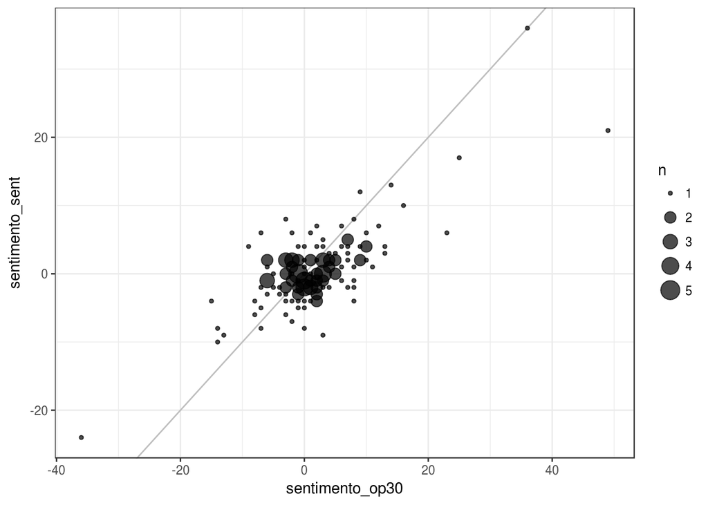

```r
reclamacoes %>%
    ggplot(aes(x = sentimento_op30, y = sentimento_sent)) +
    geom_abline(slope = 1, intercept = 0, color = "grey") +
    geom_count(alpha = .7)
```

### Comparando os valores dos léxicos normalizados

#### Normalização usual

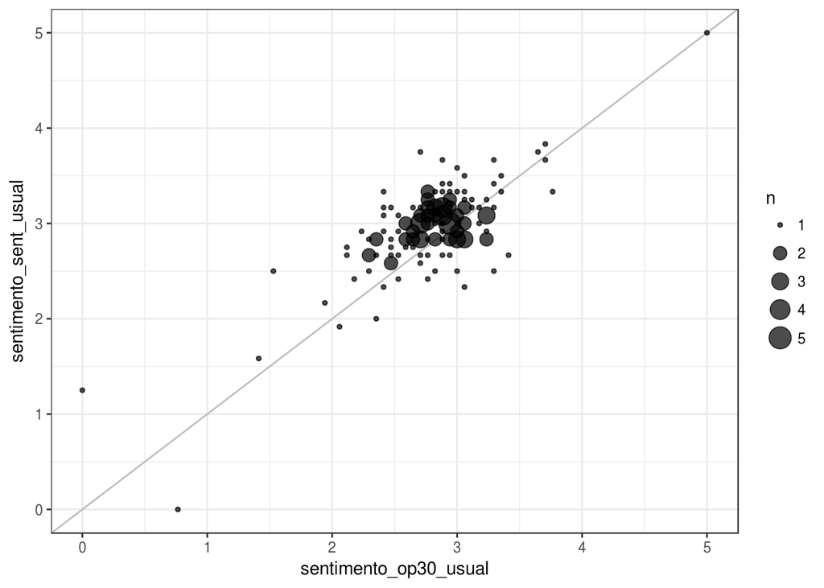

```r
reclamacoes %>%
    ggplot(aes(x = sentimento_op30_usual, y = sentimento_sent_usual)) +
    geom_abline(slope = 1, intercept = 0, color = "grey") +
    geom_count(alpha = .7)
```

### Normalização utilizando os quartis

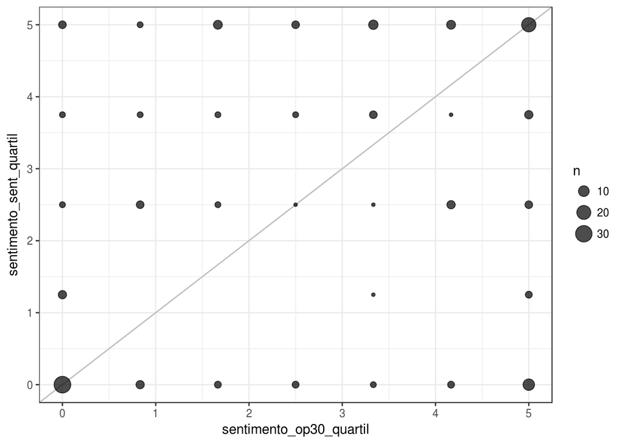

```r
reclamacoes %>%
    ggplot(aes(x = sentimento_op30_quartil, y = sentimento_sent_quartil)) +
    geom_abline(slope = 1, intercept = 0, color = "grey") +
    geom_count(alpha = .7)
```

### Erro e comparação das normalizações

### Usual

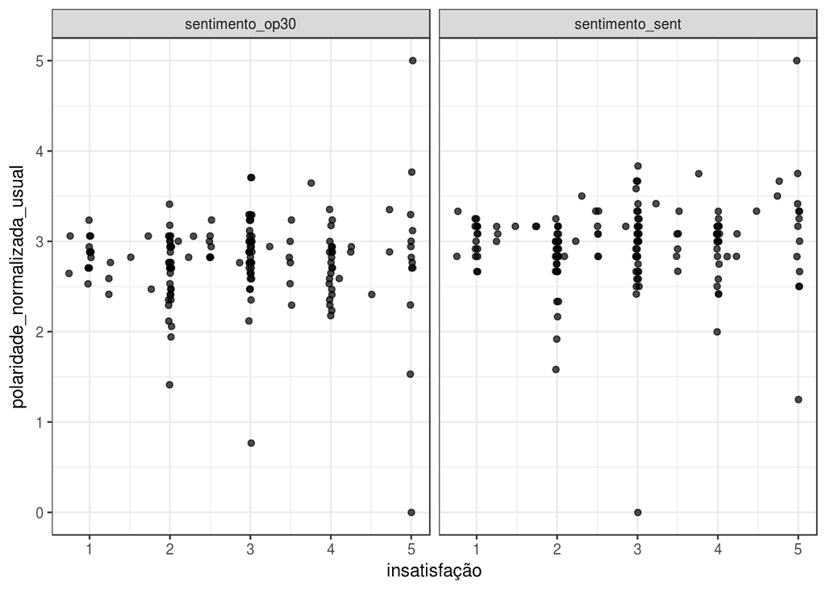

```r
reclamacoes_l %>%
    ggplot(aes(x = insatisfação, y = polaridade_normalizada_usual, group = insatisfação)) +
    geom_jitter(alpha = .7)  +
    facet_wrap(~ lexico)
```

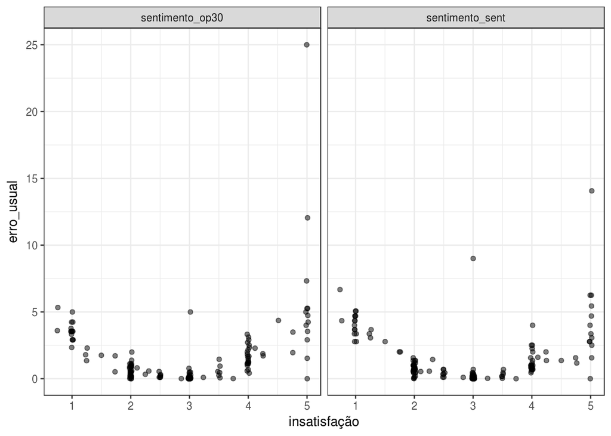

```r
reclamacoes_l %>%
    ggplot(aes(x = insatisfação, y = erro_usual, group = insatisfação)) +
    geom_jitter(alpha = .5)  +
    # geom_boxplo() +
    facet_wrap(~ lexico)
```

### Quartil

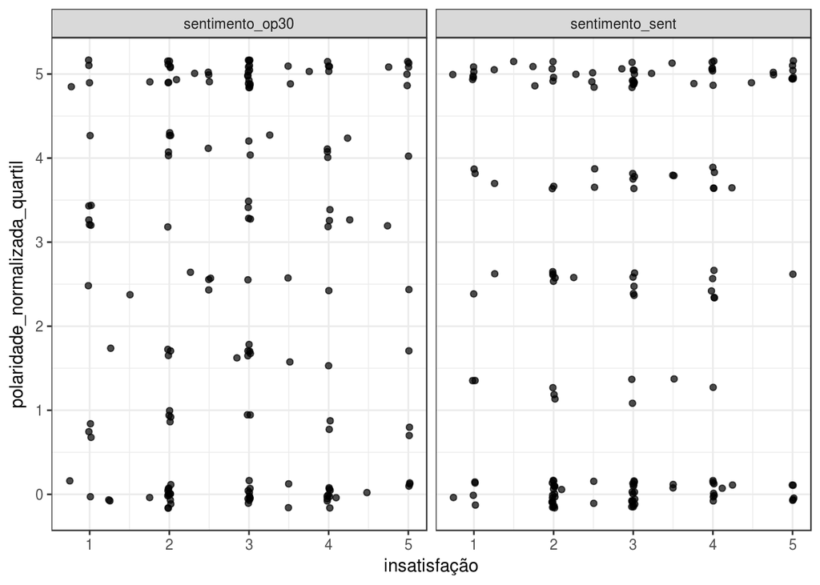

```r
reclamacoes_l %>%
    ggplot(aes(x = insatisfação, y = polaridade_normalizada_quartil, group = insatisfação)) +
    geom_jitter(alpha = .7)  +
    facet_wrap(~ lexico)
```

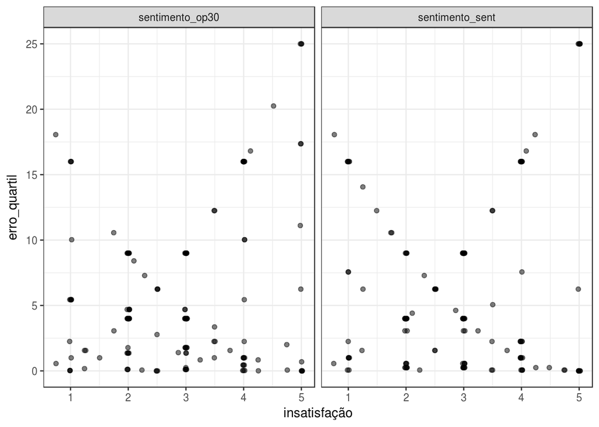

```r
reclamacoes_l %>%
    ggplot(aes(x = insatisfação, y = erro_quartil, group = insatisfação)) +
    geom_jitter(alpha = .5)  +
    # geom_boxplo() +
    facet_wrap(~ lexico)
```